# Estudios de Informática, Multimedia y Telecomunicaciones

### 2.4.4 Correlaciones

Una vez realizado el análisis exploratorio, se va a realizar las correlaciones de las características

```r
#Calculamos las correlaciones
cor_datos <- cor(datos_final)
cor_datos
```

```
##                           EDAD         SEXO TIPO DOLOR TORAX PRESIÓN ARTERIAL  CORESTEROL NIVEL DE AZÚCAR ECG EN REPOSO FREC CARDÍACA MÁX ANGINA x EJERCICIO
## EDAD                1.00000000  0.010307251       0.07064056      0.265638310  0.05557662      0.17719557    0.15301742       -0.36737055         0.18478532
## SEXO                0.01030725  1.000000000       0.14393924     -0.006190966 -0.17030775      0.10983323   -0.02065464       -0.17072969         0.18312750
## TIPO DOLOR TORAX    0.07064056  0.143939237       1.00000000      0.035017478 -0.05318981      0.14023978    0.05055787       -0.26539514         0.21247464
## PRESIÓN ARTERIAL    0.26563831 -0.006190966       0.03501748      1.000000000  0.10091912      0.09287163    0.05902914       -0.09833084         0.13454092
## CORESTEROL          0.05557662 -0.170307752      -0.05318981      0.100919123  1.00000000     -0.05485501    0.04623150        0.07215950         0.04545846
## NIVEL DE AZÚCAR     0.17719557  0.109833233       0.14023978      0.092871629 -0.05485501      1.00000000    0.03366667       -0.12336361         0.05888944
## ECG EN REPOSO       0.15301742 -0.020654643       0.05055787      0.059029140  0.04623150      0.03366667    1.00000000        0.03680226         0.02065208
## FREC CARDÍACA MÁX  -0.36737055 -0.170729692      -0.26539514     -0.098330842  0.07215950     -0.12336361    0.03680226        1.00000000        -0.37732721
## ANGINA x EJERCICIO  0.18478532  0.183127496       0.21247464      0.134540924  0.04545846      0.05888944    0.02065208       -0.37732721         1.00000000
## OLDPEAK             0.24752994  0.095590850       0.08451111      0.176890078  0.06230374      0.03594124    0.07711587       -0.18634309         0.37165510
## PENDIENTE ST        0.16103760  0.036364404      -0.03765429      0.017546990  0.04571129      0.06589316    0.04976452       -0.04619899         0.19758205
## E. CARDIACA         0.15913980  0.144474318       0.40242504      0.053535720 -0.03116443      0.20237228    0.07378645       -0.20844073         0.27053481
##                        OLDPEAK PENDIENTE ST E. CARDIACA
## EDAD                0.24752994   0.16103760  0.15913980
## SEXO                0.09559085   0.03636440  0.14447432
## TIPO DOLOR TORAX    0.08451111  -0.03765429  0.40242504
## PRESIÓN ARTERIAL    0.17689008   0.01754699  0.05353572
## CORESTEROL          0.06230374   0.04571129 -0.03116443
## NIVEL DE AZÚCAR     0.03594124   0.06589316  0.20237228
## ECG EN REPOSO       0.07711587   0.04976452  0.07378645
## FREC CARDÍACA MÁX  -0.18634309  -0.04619899 -0.20844073
## ANGINA x EJERCICIO  0.37165510   0.19758205  0.27053481
## OLDPEAK             1.00000000   0.21639692  0.18230327
## PENDIENTE ST        0.21639692   1.00000000  0.44099197
## E. CARDIACA         0.18230327   0.44099197  1.00000000
```

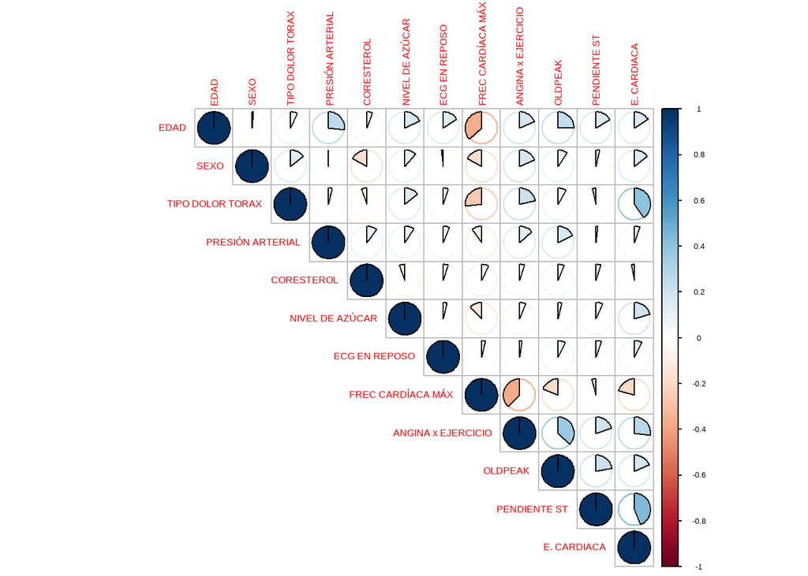

```r
#Representación de las correlaciones
corrplot(cor_datos, method = "pie", type="upper")
```

[figure not shown]

```r
#Representación de las correlaciones II
corrplot(cor_datos, method = 'shade', order = 'AOE')
```

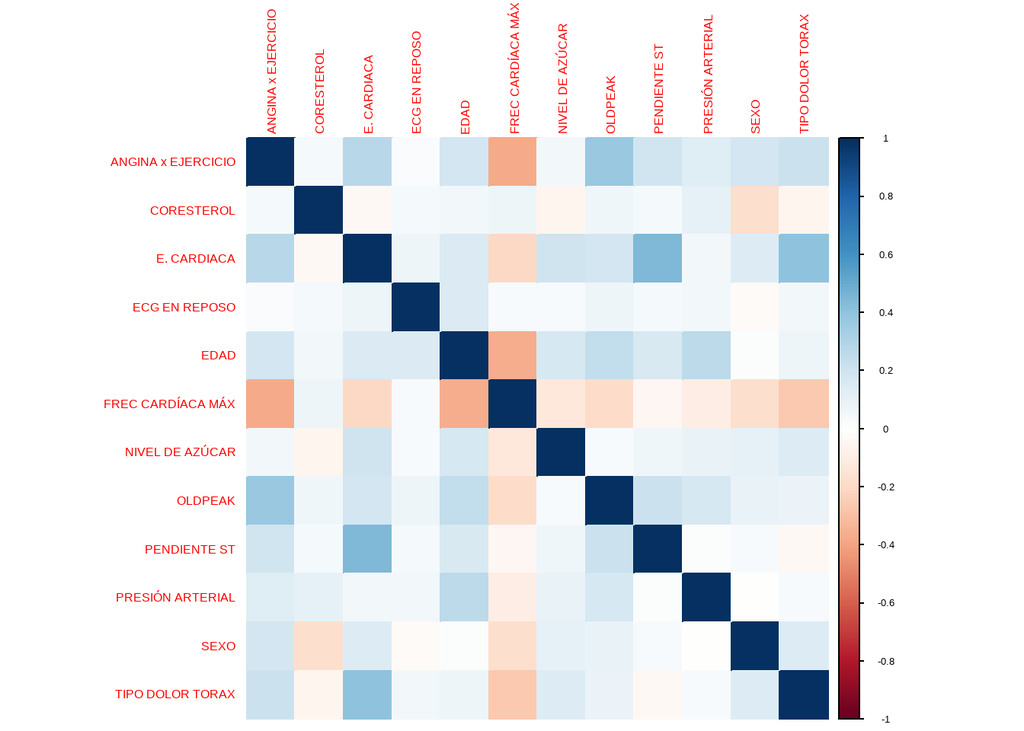

```r
#Representación de las correlaciones III
corrplot(cor_datos, method = 'color', order = 'alphabet')
```

Para representar las correlaciones, se ha usado diferentes métodos para ver las relaciones entre las características y verlo de una manera más clara.

### 2.4.5 Análisis de componentes principales (PCA)

Ahora se va a realizar un análisis de componentes sobre el conjunto de datos final. Lo primero que vamos a calcular es la varianza de todas las caracteristicas

```r
#Cálculo de la varianza de los componentes.
var <- apply(datos_final, 2, var)
var
```

```
##               EDAD               SEXO   TIPO DOLOR TORAX   PRESIÓN ARTERIAL         CORESTEROL    NIVEL DE AZÚCAR      ECG EN REPOSO  FREC CARDÍACA MÁX
##         87.4315033          0.1808166          1.2233549        319.6802285       3071.0066876          0.1672628          0.5577678        647.8786644
## ANGINA x EJERCICIO            OLDPEAK       PENDIENTE ST        E. CARDIACA
##          0.2369530          1.1930804          0.4791289          0.2475826
```

Como se puede observar de una manera bastante clara, el colesterol es la característica que mas varia de un individuo a otro.

Lo siguiente es centrar y escalar las características, para que así las variables pierdan esa variabilidad. Una vez calculada la matriz se la asigno al pca

```r
#Calculo de la descomposición de los componentes
pca <- prcomp(datos_final, scale = TRUE, center = TRUE)
pca
```

```
## Standard deviations (1, .., p=12):
##  [1] 1.6004587 1.1848672 1.0951841 1.0481039 0.9890992 0.9745326 0.9269463 0.8877397 0.8482690 0.7815714 0.6725318 0.6153182
##
## Rotation (n x k) = (12 x 12):
##                            PC1         PC2         PC3         PC4         PC5         PC6          PC7         PC8         PC9        PC10        PC11        PC12
## EDAD                0.34186886 -0.31597048  0.27284093 -0.19719939  0.22036848 -0.03054682  0.394699966 -0.08280293  0.22183975  0.36136298 -0.52567759 -0.04105846
## SEXO                0.19695232  0.41874758  0.10159710  0.15624946  0.27521660  0.29068895 -0.504704790 -0.26613424  0.47328322  0.20038552 -0.03160227  0.01325580
## TIPO DOLOR TORAX    0.29666462  0.35074626  0.05130859 -0.20673459 -0.62151831 -0.01899374 -0.054090760  0.21433908 -0.07062946  0.25414392 -0.13918932  0.46811458
## PRESIÓN ARTERIAL    0.19450631 -0.38116848  0.34117489 -0.12963613  0.09326520 -0.14196344 -0.451908479  0.59104748  0.20098241 -0.19698004  0.14233904  0.04249900
## CORESTEROL         -0.00374595 -0.49964402 -0.11013691  0.06643287 -0.48129712 -0.26512415 -0.280661867 -0.51650117  0.25923726  0.10709899  0.08476148 -0.02138766
## NIVEL DE AZÚCAR     0.21033679  0.13463534  0.08129254 -0.55672296  0.28629720 -0.36105881 -0.243445587 -0.39721389 -0.40491044 -0.14495703  0.05220850  0.06338703
## ECG EN REPOSO       0.09336401 -0.24452791 -0.10070730 -0.47737624 -0.12088456  0.77374750  0.032622175 -0.11710842  0.01879421 -0.20963938  0.14467617  0.01221850
## FREC CARDÍACA MÁX  -0.38060216 -0.12436986 -0.37924919 -0.14428722  0.06495553  0.08338277 -0.443236654  0.16417138 -0.17641796  0.15005294 -0.62169000 -0.01746038
## ANGINA x EJERCICIO  0.40752387 -0.01395628  0.04453332  0.40393678 -0.13276279  0.08562358 -0.068550323 -0.12478324 -0.18542885 -0.62077660 -0.45065005 -0.02282787
## OLDPEAK             0.34104005 -0.25190114 -0.02266335  0.34168704  0.10252245  0.21743906 -0.169711382  0.02498367 -0.57518714  0.48245931  0.22445107 -0.04209029
## PENDIENTE ST        0.27131324 -0.14004149 -0.64813472  0.06883012  0.31757589 -0.11948995  0.115175138  0.06047606  0.19934936 -0.08228308  0.10069380  0.54153156
## E. CARDIACA         0.40579248  0.17380336 -0.44823765 -0.17158263 -0.13882935 -0.13737285  0.003426377  0.20485733  0.11751791  0.04498669  0.04568829 -0.69045089
```

Se puede ver que la primera componente tiene la mayor desviación estándar de todos los componentes. Para verlo de una manera mas clara, se va a representar de una manera grafica la salida anterior

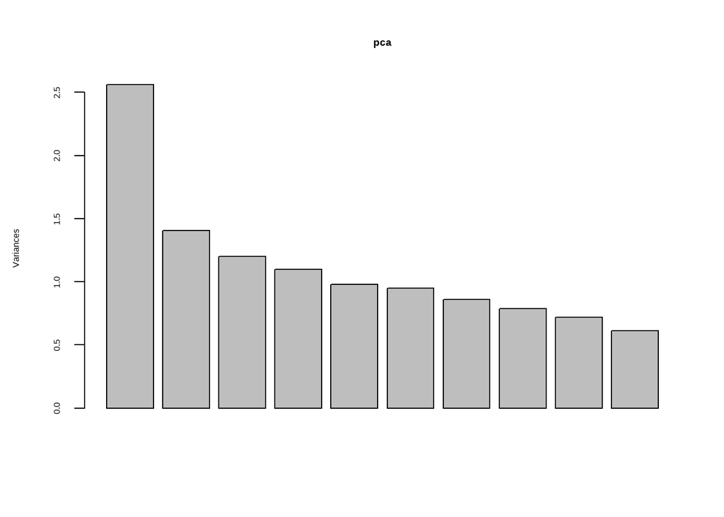

```r
#Representación PCA´s anteriores
screeplot(pca)
```

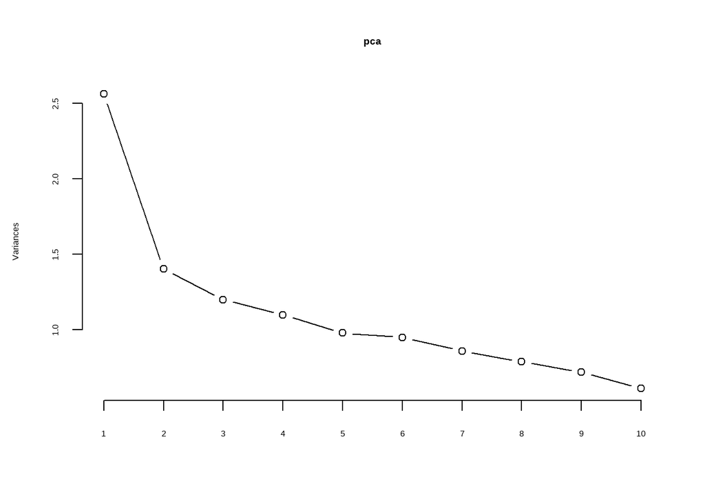

```r
plot(pca, type = "l")
```

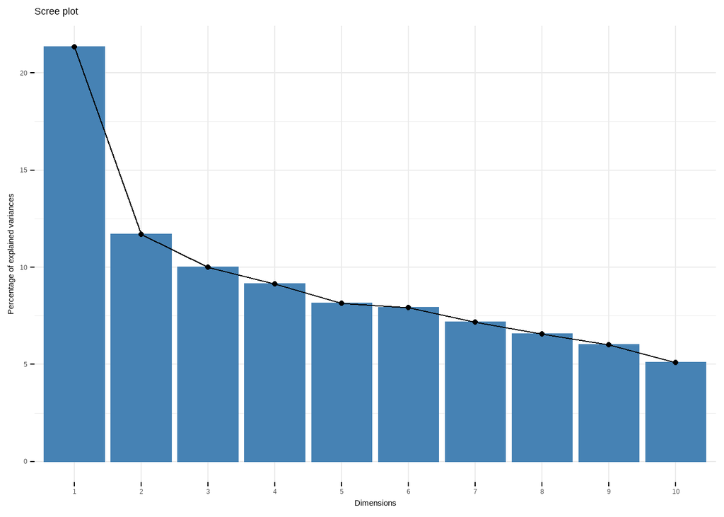

```r
#Juntamos las dos gráficas anteriores
fviz_eig(pca)
```

Como se ha dicho antes, tanto de una manera numérica como gráfica, el PC1 es el que mejor de todos con una diferencia notable. Si usamos la técnica del codo, deberíamos coger solamente las dos primeras componentes.

Para confirmar la interpretación, no estaría de más obtener las estadísticas de todas las componentes

```r
#Estadísticas de las componentes
summary(pca)
```

```
## Importance of components:
##                           PC1    PC2     PC3     PC4     PC5     PC6    PC7     PC8     PC9   PC10    PC11    PC12
## Standard deviation     1.6005 1.1849 1.09518 1.04810 0.98910 0.97453 0.9269 0.88774 0.84827 0.7816 0.67253 0.61532
## Proportion of Variance 0.2135 0.1170 0.09995 0.09154 0.08153 0.07914 0.0716 0.06567 0.05996 0.0509 0.03769 0.03155
## Cumulative Proportion  0.2135 0.3305 0.43040 0.52194 0.60347 0.68261 0.7542 0.81989 0.87985 0.9308 0.96845 1.00000
```

Viendo las estadísticas vemos que con las dos primeras componentes solamente podríamos explicar un 33,05% de los datos.Como no queremos perder información en el modelo, nos tendríamos que quedar con todas las componentes.

Para verlo de una manera visual, se va a representar la PCA de una manera gráfica.

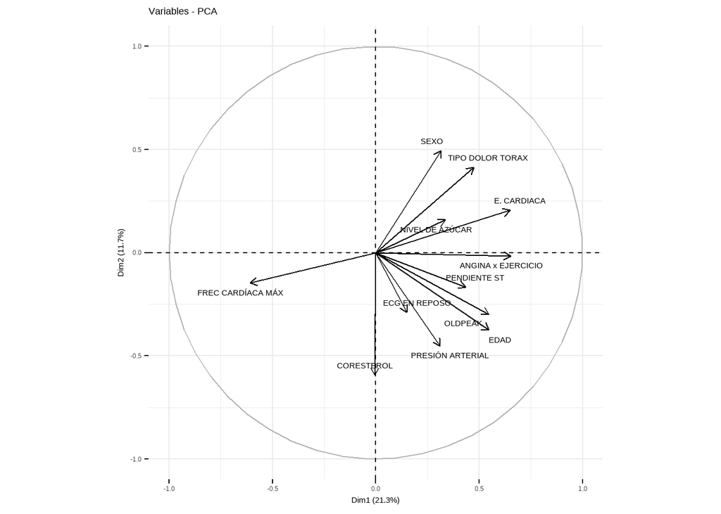

```r
#Representación de variables sobre componentes principales
fviz_pca_var(pca, repel = TRUE, scale = 0)
```

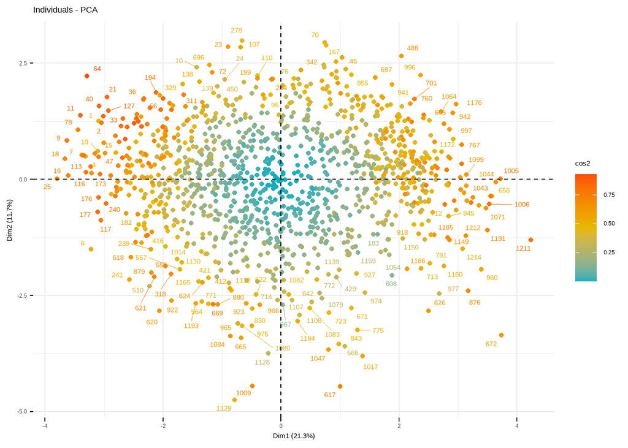

```r
#Representación de observaciones sobre componentes principales
fviz_pca_ind(pca, col.ind = "cos2", gradient.cols = c("#00AFBB", "#E7B800", "#FC4E07"), repel = TRUE)
```

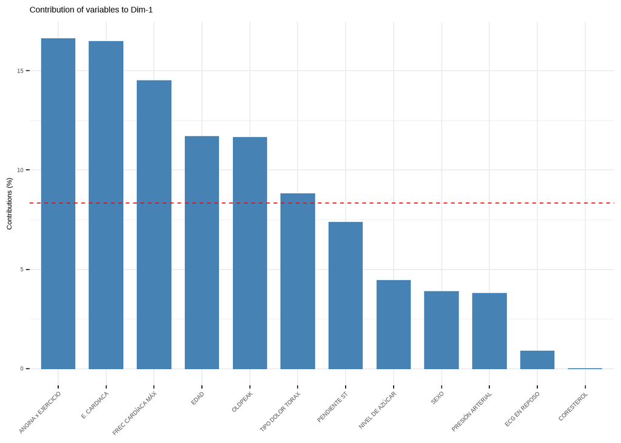

```r
#Representa la contribución de filas/columnas de los resultados de un pca
fviz_contrib(pca,choice = "var")
```

Una vez que hemos representada las variables y los individuos, se va a fusionar estas dos gráficas

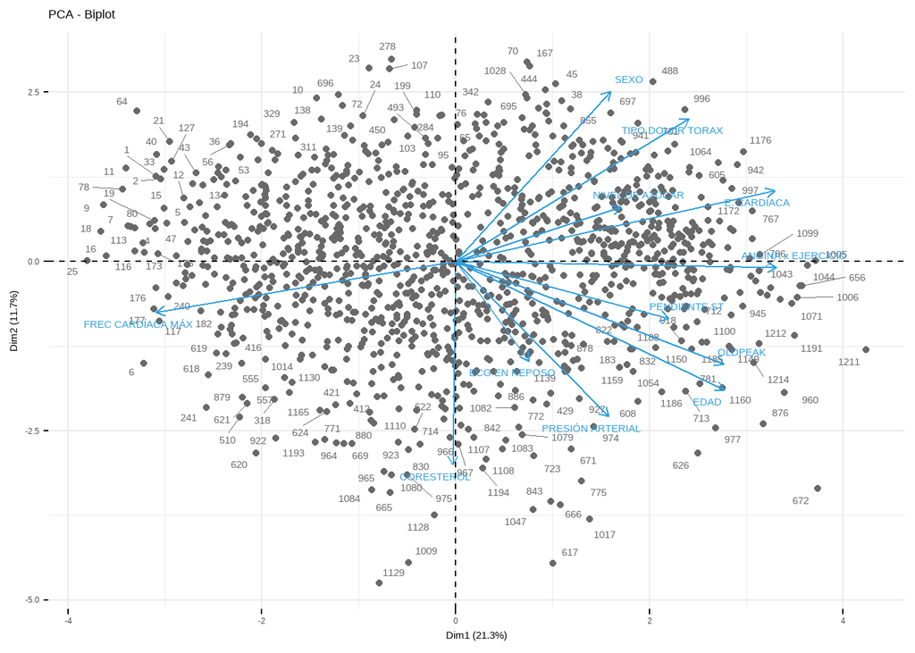

```r
#Representación de variables y los individuos en la misma gráfica
fviz_pca_biplot(pca, repel = TRUE, col.var = "#2E9FDF", col.ind = "#696969")
```

Aunque la opción de repelerse esta activada al ser bastantes casos no se puede ver una manera correcta, así que se a mostrar solamente los 10, 20 y 30 casos más influyentes

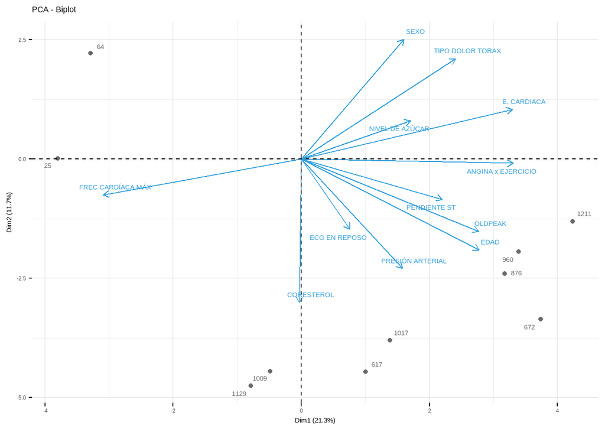

```r
#Representación de variables y los 10 individuos más influyentes en la misma gráfica
fviz_pca_biplot(pca, repel = TRUE, col.var = "#2E9FDF", col.ind = "#696969", select.ind = list(contrib = 10))
```

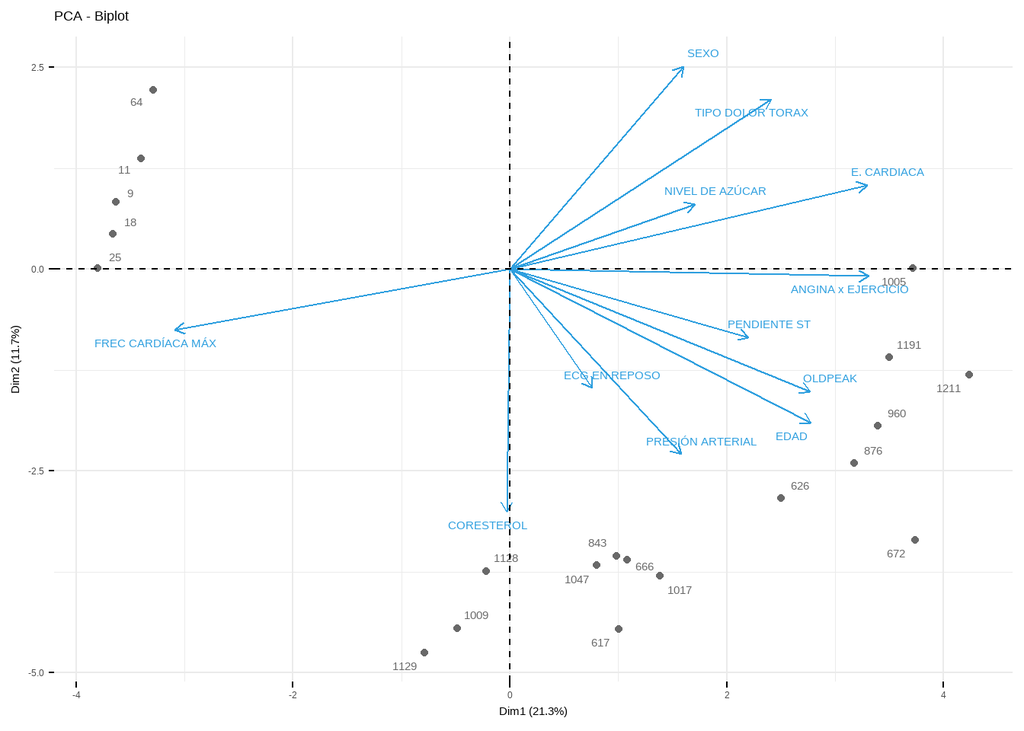

```r
#Representación de variables y los 10 individuos más influyentes en la misma gráfica
fviz_pca_biplot(pca, repel = TRUE, col.var = "#2E9FDF", col.ind = "#696969", select.ind = list(contrib = 20))
```

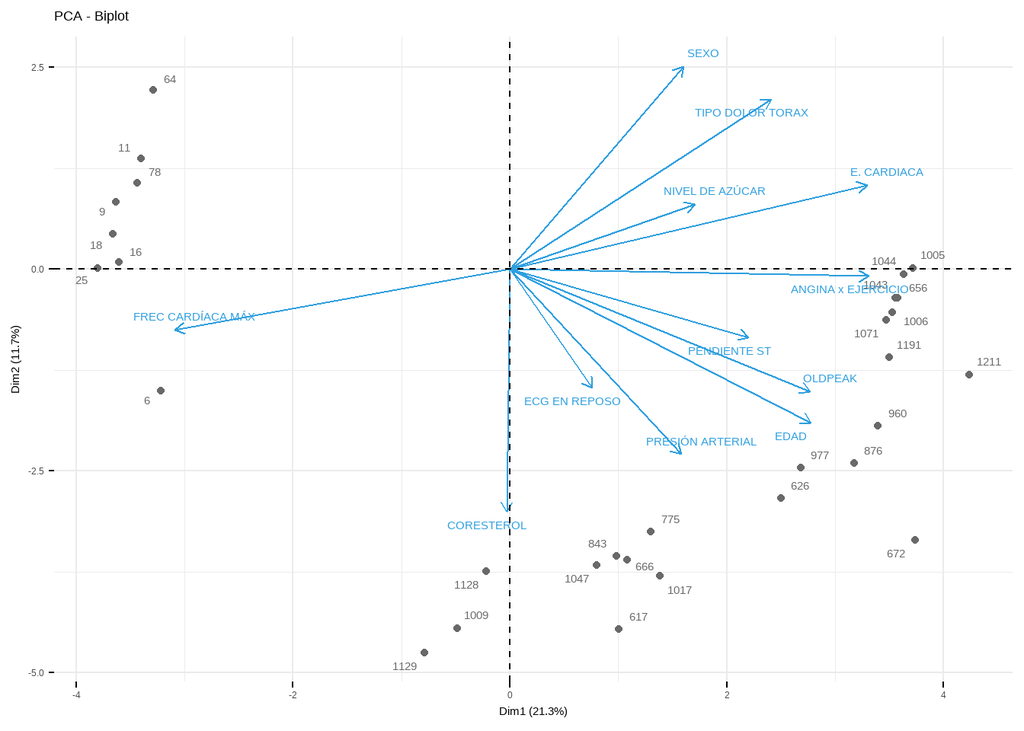

```r
#Representación de variables y los 10 individuos más influyentes en la misma gráfica
fviz_pca_biplot(pca, repel = TRUE, col.var = "#2E9FDF", col.ind = "#696969", select.ind = list(contrib = 30))
```

Al mostrar solamente los casos mas influyentes, se puede ver con mas claridad las relaciones entre los individuos y las características.

Podemos concluir de este análisis de componentes, que no se puede quitar ninguna característica ya que se perdería información.

# 3 Conclusiones

Una vez realizado todos los procedimientos anteriores, se ha obtenido un conjunto de datos ya preparados poder aplicar algoritmos (de clustering, regresión o clasificación) sin perder nunca de vista el objetivo que se pretende alcanzar en este estudio.

# 4 Criterios de evaluación

- 10%. Justificación de la elección del juego de datos donde se detalle el potencial analítico que se intuye.
- 10% Se plantea un problema propio de minería de datos, se detallan los objetivos analíticos y se explica detalladamente el procedimiento para darles solución.
- 20%. Información extraída del análisis exploratorio. Distribuciones, correlaciones, anomalías …
- 20%. Explicación clara de cualquier tarea de limpieza, acondicionado o transformación que se realiza sobre los datos, justificando el motivo y mencionando las ventajas de la acción tomada.
- 20%. Se realiza un proceso de PCA o SVD donde se aprecia mediante explicaciones y comentarios que el estudiante entiende todos los pasos y se comenta extensamente el resultado final obtenido. Se usan las componentes obtenidas para apoyar el análisis propuesto.
- 20%. Se obtiene un conjunto de datos preparado y descrito adecuadamente, especificando las variables que se usarán en los procesos de modelado posterior, y como se aplicarán los métodos propuestos sobre ellas.